# CS 397F Chernoff Faces

Vincent Lee

### Chernoff Faces

Humans have built-in facial recognition in their brains. We are programmed to respond to facial features. Herman Chernoff, a statistician and physicist, came up with the idea of representing data with cortoon-like faces.

```r
library(aplpack)
crime.df <- read.csv("crimeRatesByState.csv")
str(crime.df)
```

```
## 'data.frame':    52 obs. of  7 variables:
##  $ state              : Factor w/ 52 levels "Alabama ","Alaska ",..: 45 1 2 3 4 5 6 7 9 8 ...
##  $ murder             : num  5.6 8.2 4.8 7.5 6.7 6.9 3.7 2.9 4.4 35.4 ...
##  $ robbery            : num  140.7 141.4 80.9 144.4 91.1 ...
##  $ aggravated_assault : num  291 248 465 327 387 ...
##  $ burglary           : num  727 954 622 948 1085 ...
##  $ larceny_theft      : num  2286 2650 2599 2965 2711 ...
##  $ motor_vehicle_theft: num  417 288 391 924 262 ...
```

Generate faces on the data. The first column will be the labels.

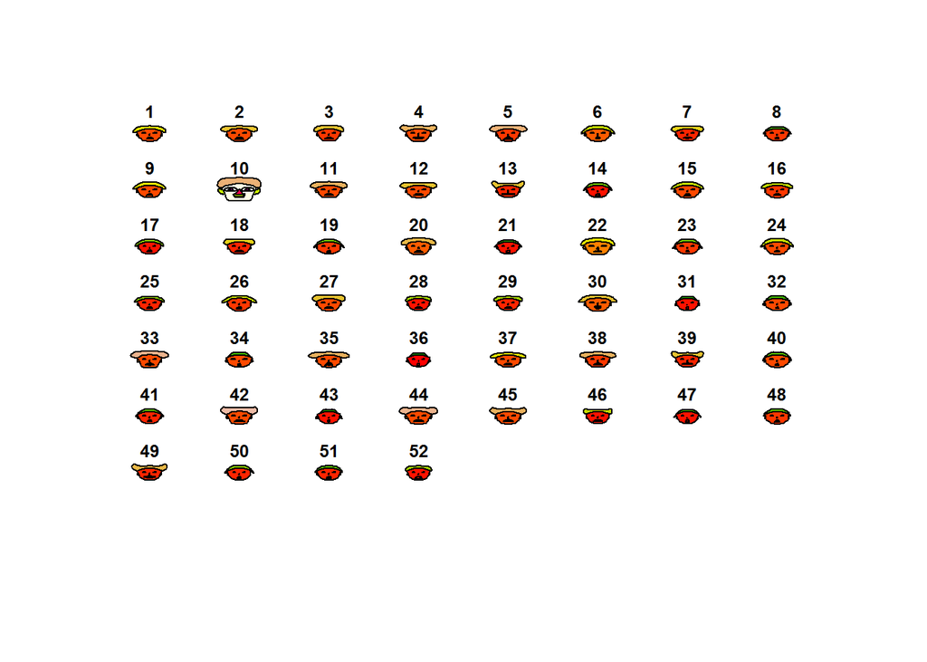

```
## effect of variables:
##  modified item       Var
##  "height of face   " "murder"
##  "width of face    " "robbery"
##  "structure of face" "aggravated_assault"
##  "height of mouth  " "burglary"
##  "width of mouth   " "larceny_theft"
##  "smiling          " "motor_vehicle_theft"
##  "height of eyes   " "murder"
##  "width of eyes    " "robbery"
##  "height of hair   " "aggravated_assault"
##  "width of hair   "  "burglary"
##  "style of hair   "  "larceny_theft"
##  "height of nose  "  "motor_vehicle_theft"
##  "width of nose   "  "murder"
##  "width of ear    "  "robbery"
##  "height of ear   "  "aggravated_assault"
```

```r
faces(crime.df[,2:7])
```

Change to no color.

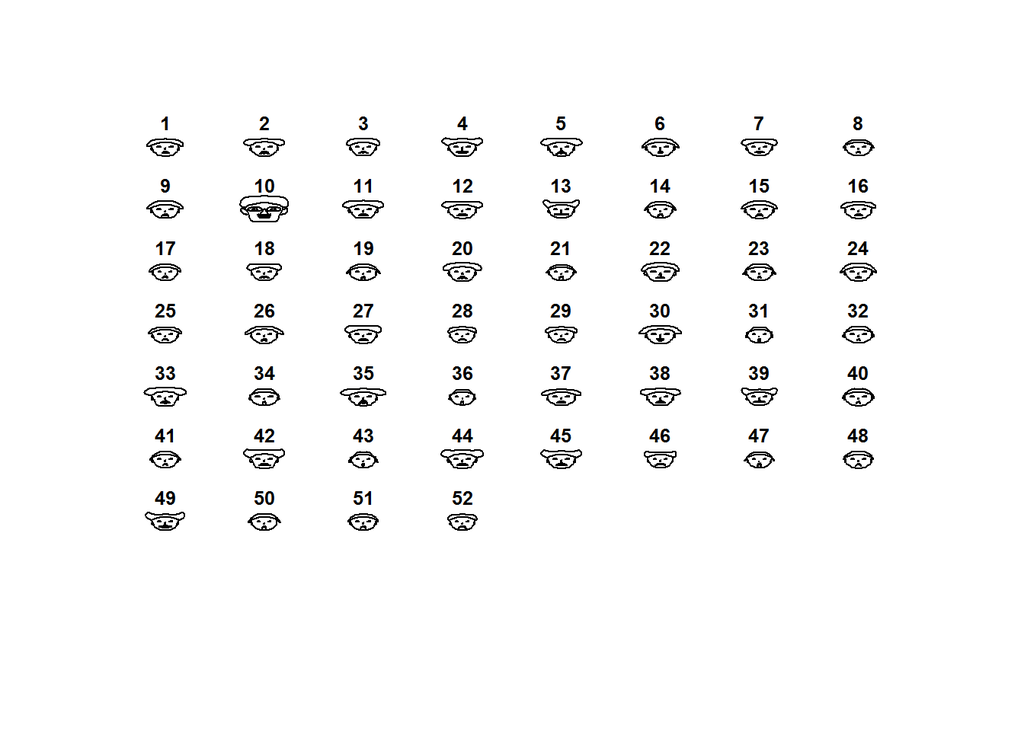

```
## effect of variables:
##  modified item       Var
##  "height of face   " "murder"
##  "width of face    " "robbery"
##  "structure of face" "aggravated_assault"
##  "height of mouth  " "burglary"
##  "width of mouth   " "larceny_theft"
##  "smiling          " "motor_vehicle_theft"
##  "height of eyes   " "murder"
##  "width of eyes    " "robbery"
##  "height of hair   " "aggravated_assault"
##  "width of hair   "  "burglary"
##  "style of hair   "  "larceny_theft"
##  "height of nose  "  "motor_vehicle_theft"
##  "width of nose   "  "murder"
##  "width of ear    "  "robbery"
##  "height of ear   "  "aggravated_assault"
```

```r
faces(crime.df[,2:7],face.type=0)
```

Now add labels instead of the index numbers.

[figure not shown]

```
## effect of variables:
##  modified item       Var
##  "height of face   " "murder"
##  "width of face    " "robbery"
##  "structure of face" "aggravated_assault"
##  "height of mouth  " "burglary"
##  "width of mouth   " "larceny_theft"
##  "smiling          " "motor_vehicle_theft"
##  "height of eyes   " "murder"
##  "width of eyes    " "robbery"
##  "height of hair   " "aggravated_assault"
##  "width of hair   "  "burglary"
##  "style of hair   "  "larceny_theft"
##  "height of nose  "  "motor_vehicle_theft"
##  "width of nose   "  "murder"
##  "width of ear    "  "robbery"
##  "height of ear   "  "aggravated_assault"
```

```r
faces(crime.df[,2:7], labels=crime.df$state)
```

Smiling is the sixth feature in the list of features used by the faces function. We will not use the first column of the data set for the faces function as it contains the labels, so we need to add a ones column at column number 7 to neutralize smiling.

[figure not shown]

```
## effect of variables:
##  modified item       Var
##  "height of face   " "murder"
##  "width of face    " "robbery"
##  "structure of face" "aggravated_assault"
##  "height of mouth  " "burglary"
##  "width of mouth   " "larceny_theft"
##  "smiling          " "rep(1, length(crime.df$state))"
##  "height of eyes   " "crime.df[, 7]"
##  "width of eyes    " "murder"
##  "height of hair   " "robbery"
##  "width of hair   "  "aggravated_assault"
##  "style of hair   "  "burglary"
##  "height of nose  "  "larceny_theft"
##  "width of nose   "  "rep(1, length(crime.df$state))"
##  "width of ear    "  "crime.df[, 7]"
##  "height of ear   "  "murder"
```

```r
crime.nosmile <- cbind(crime.df[,1:6], rep(1, length(crime.df$state)), crime.df[,7])
faces(crime.nosmile[,2:8], labels=crime.nosmile$state)
```

What if we want to use a subset of the columns, just murder, burglary, and motor vehicle theft?

Because the data size is less than the facial features, the data columns rotate. To control this, create a matrix with all constant values, then fill in the coluns we want to display as a facial feature with data.

```r
mat.to.plot <- matrix(1,nrow=nrow(crime.df),ncol=15) #all values are 1 (default)
rownames(mat.to.plot)<- crime.df$state
```

Now add the data at the column that corresponds to the facial feature we want.

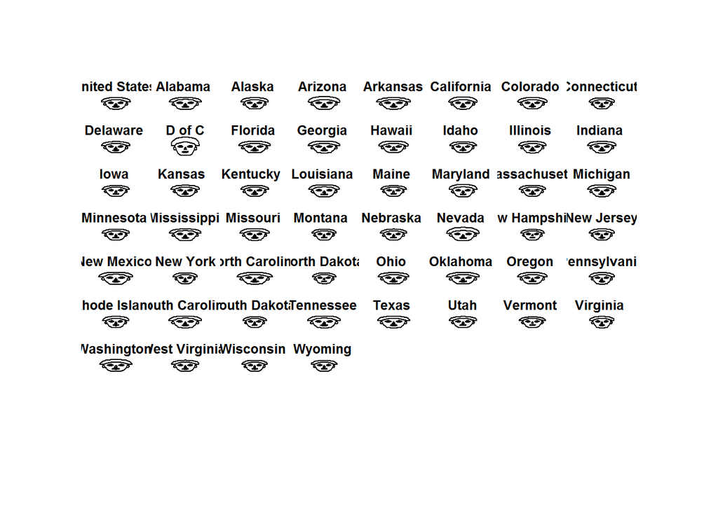

```
## effect of variables:
##  modified item       Var
##  "height of face   " "Var1"
##  "width of face    " "Var2"
##  "structure of face" "Var3"
##  "height of mouth  " "Var4"
##  "width of mouth   " "Var5"
##  "smiling          " "Var6"
##  "height of eyes   " "Var7"
##  "width of eyes    " "Var8"
##  "height of hair   " "Var9"
##  "width of hair   "  "Var10"
##  "style of hair   "  "Var11"
##  "height of nose  "  "Var12"
##  "width of nose   "  "Var13"
##  "width of ear    "  "Var14"
##  "height of ear   "  "Var15"
```

```r
mat.to.plot[,1]<-crime.df[,2]
mat.to.plot[,2]<-crime.df[,5]
mat.to.plot[,9]<-crime.df[,7]

faces(mat.to.plot,face.type=0)
```

This type of plotting is best for identifying faces that “stand-out” from the rest rather than assessing one or two variables.

Now use the state_data.csv data set to produce some Chernoff faces. Start by using all of the data, with the state abbreviations as the labels. Then, pick a subset of the data and plot the faces for that subset.

```r
state <- read.csv("state_data.csv")
str(state)
```

```
## 'data.frame':    50 obs. of  9 variables:
##  $ State     : Factor w/ 50 levels "AK","AL","AR",..: 2 1 4 3 5 6 7 8 9 10 ...
##  $ Population: int  3615 365 2212 2110 21198 2541 3100 579 8277 4931 ...
##  $ Income    : int  3624 6315 4530 3378 5114 4884 5348 4809 4815 4091 ...
##  $ Illiteracy: num  2.1 1.5 1.8 1.9 1.1 0.7 1.1 0.9 1.3 2 ...
##  $ Life.Exp  : num  69 69.3 70.5 70.7 71.7 ...
##  $ Murder    : num  15.1 11.3 7.8 10.1 10.3 6.8 3.1 6.2 10.7 13.9 ...
##  $ HS.Grad   : num  41.3 66.7 58.1 39.9 62.6 63.9 56 54.6 52.6 40.6 ...
##  $ Frost     : int  20 152 15 65 20 166 139 103 11 60 ...
##  $ Area      : int  50708 566432 113417 51945 156361 103766 4862 1982 54090 58073 ...
```

```r
#head(state)
#dim(state)
```

Generate faces on the data. The first column will be the labels.

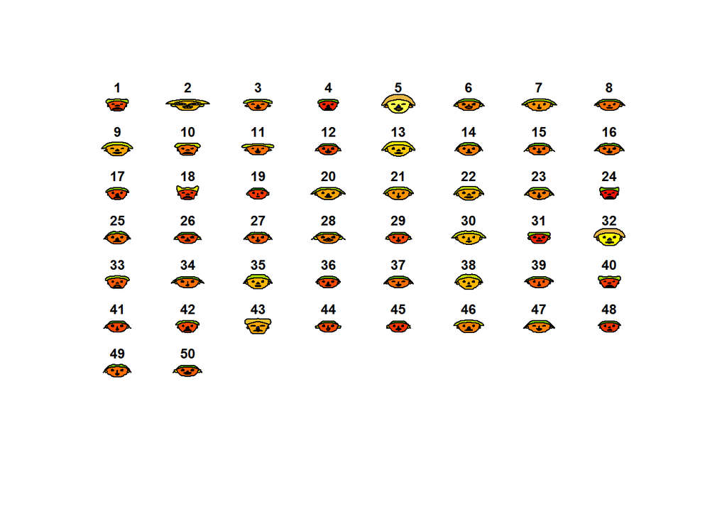

```
## effect of variables:
##  modified item       Var
##  "height of face   " "Population"
##  "width of face    " "Income"
##  "structure of face" "Illiteracy"
##  "height of mouth  " "Life.Exp"
##  "width of mouth   " "Murder"
##  "smiling          " "HS.Grad"
##  "height of eyes   " "Frost"
##  "width of eyes    " "Area"
##  "height of hair   " "Population"
##  "width of hair   "  "Income"
##  "style of hair   "  "Illiteracy"
##  "height of nose  "  "Life.Exp"
##  "width of nose   "  "Murder"
##  "width of ear    "  "HS.Grad"
##  "height of ear   "  "Frost"
```

```r
faces(state[,2:9])
```

No color.

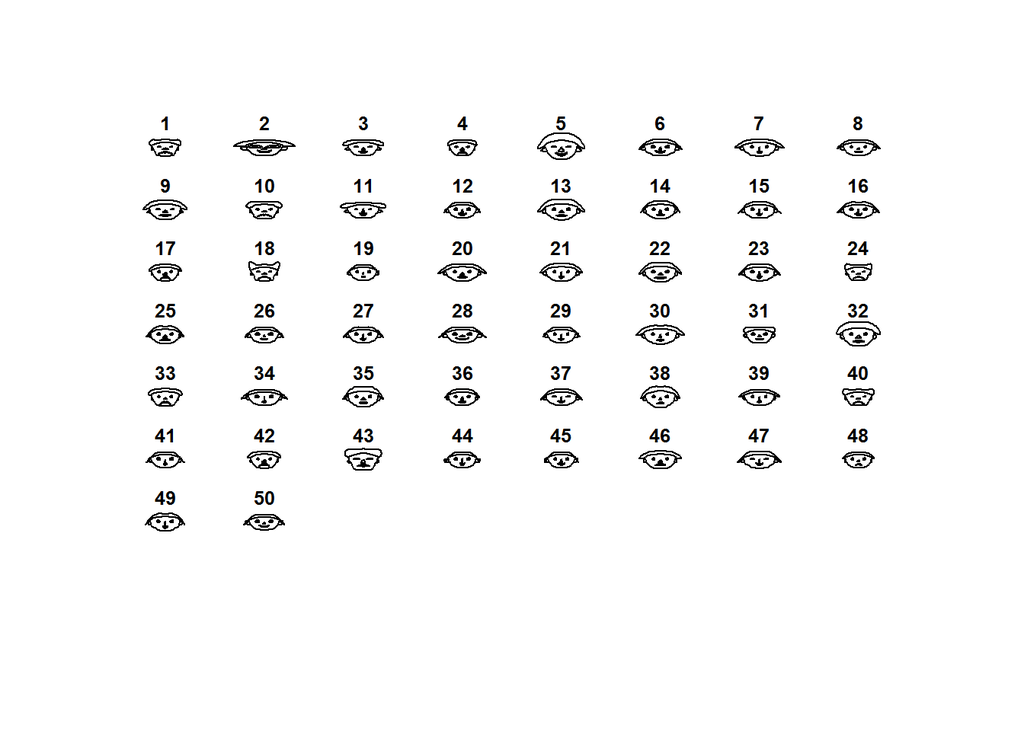

```
## effect of variables:
##  modified item       Var
##  "height of face   " "Population"
##  "width of face    " "Income"
##  "structure of face" "Illiteracy"
##  "height of mouth  " "Life.Exp"
##  "width of mouth   " "Murder"
##  "smiling          " "HS.Grad"
##  "height of eyes   " "Frost"
##  "width of eyes    " "Area"
##  "height of hair   " "Population"
##  "width of hair   "  "Income"
##  "style of hair   "  "Illiteracy"
##  "height of nose  "  "Life.Exp"
##  "width of nose   "  "Murder"
##  "width of ear    "  "HS.Grad"
##  "height of ear   "  "Frost"
```

```r
faces(state[,2:9],face.type=0)
```

Labels instead of the index numbers.

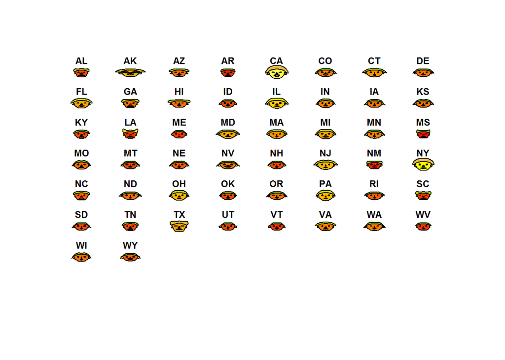

```
## effect of variables:
##  modified item       Var
##  "height of face   " "Population"
##  "width of face    " "Income"
##  "structure of face" "Illiteracy"
##  "height of mouth  " "Life.Exp"
##  "width of mouth   " "Murder"
##  "smiling          " "HS.Grad"
##  "height of eyes   " "Frost"
##  "width of eyes    " "Area"
##  "height of hair   " "Population"
##  "width of hair   "  "Income"
##  "style of hair   "  "Illiteracy"
##  "height of nose  "  "Life.Exp"
##  "width of nose   "  "Murder"
##  "width of ear    "  "HS.Grad"
##  "height of ear   "  "Frost"
```

```r
faces(state[,2:9], labels=state$State)
```

Smiling is the sixth feature in the list of features used by the faces function. We will not use the first column of the data set for the faces function as it contains the labels, so we need to add a ones column at column number 7 to neutralize smiling.

[figure not shown]

```
## effect of variables:
##  modified item       Var
##  "height of face   " "Population"
##  "width of face    " "Income"
##  "structure of face" "Illiteracy"
##  "height of mouth  " "Life.Exp"
##  "width of mouth   " "Murder"
##  "smiling          " "rep(1, length(state$State))"
##  "height of eyes   " "state[, 7]"
##  "width of eyes    " "Population"
##  "height of hair   " "Income"
##  "width of hair   "  "Illiteracy"
##  "style of hair   "  "Life.Exp"
##  "height of nose  "  "Murder"
##  "width of nose   "  "rep(1, length(state$State))"
##  "width of ear    "  "state[, 7]"
##  "height of ear   "  "Population"
```

```r
crime.nosmile2 <- cbind(state[,1:6], rep(1, length(state$State)), state[,7])
faces(crime.nosmile2[,2:8], labels=crime.nosmile2$State)
```

Because the data size is less than the facial features, the data columns rotate. To control this, create a matrix with all constant values, then fill in the coluns we want to display as a facial feature with data.

```r
mat.to.plot2 <- matrix(1,nrow=nrow(state),ncol=15) #all values are 1 (default)
rownames(mat.to.plot2)<- state$state
```

Now add the data at the column that corresponds to the facial feature we want.

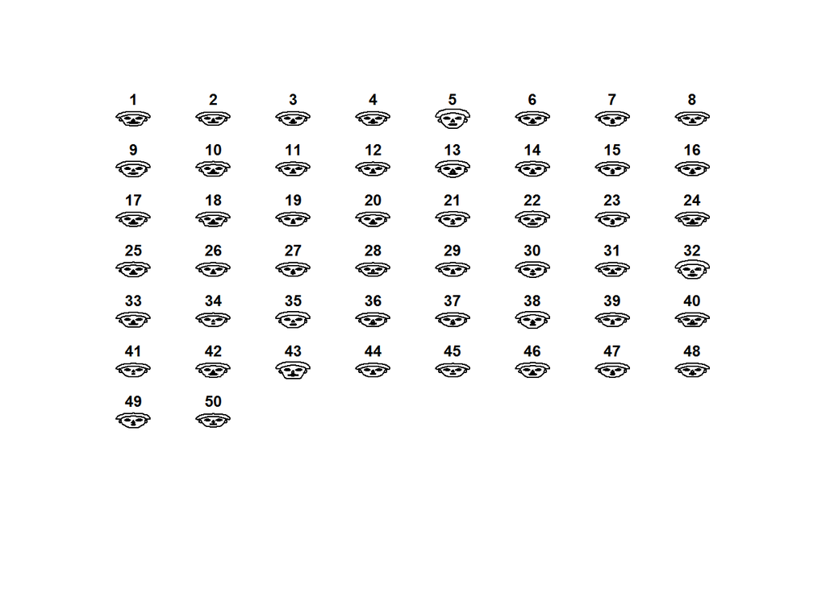

```
## effect of variables:
##  modified item       Var
##  "height of face   " "Var1"
##  "width of face    " "Var2"
##  "structure of face" "Var3"
##  "height of mouth  " "Var4"
##  "width of mouth   " "Var5"
##  "smiling          " "Var6"
##  "height of eyes   " "Var7"
##  "width of eyes    " "Var8"
##  "height of hair   " "Var9"
##  "width of hair   "  "Var10"
##  "style of hair   "  "Var11"
##  "height of nose  "  "Var12"
##  "width of nose   "  "Var13"
##  "width of ear    "  "Var14"
##  "height of ear   "  "Var15"
```

```r
mat.to.plot2[,1]<-state[,2]
mat.to.plot2[,3]<-state[,4]
mat.to.plot2[,5]<-state[,6]

faces(mat.to.plot2,face.type=0)
```

Next, try the NFC-OffenseData.csv and NFC-DefenseData.csv data sets. Add titles to the plots. What can you say about these team’s offense and defense last year?

```r
NFC.off <- read.csv("NFC-OffenseData.csv")
str(NFC.off)
```

```
## 'data.frame':    16 obs. of  9 variables:
##  $ Team   : Factor w/ 16 levels "49ers","Bears",..: 4 14 15 3 7 8 11 6 13 9 ...
##  $ TotPts : int  489 408 423 342 339 420 500 377 388 358 ...
##  $ PtsG   : num  30.6 25.5 26.4 21.4 21.2 26.2 31.2 23.6 24.2 22.4 ...
##  $ RushYds: int  1917 1491 2268 2162 1606 1609 2282 1743 1566 1335 ...
##  $ RYdsG  : num  119.8 93.2 141.8 135.1 100.4 ...
##  $ PassYds: int  4616 4970 3790 3852 4379 4343 3589 4087 4095 4212 ...
##  $ PYdsG  : num  288 311 237 241 274 ...
##  $ TotYds : int  6533 6461 6058 6014 5985 5952 5871 5830 5661 5547 ...
##  $ YdsG   : num  408 404 379 376 374 ...
```

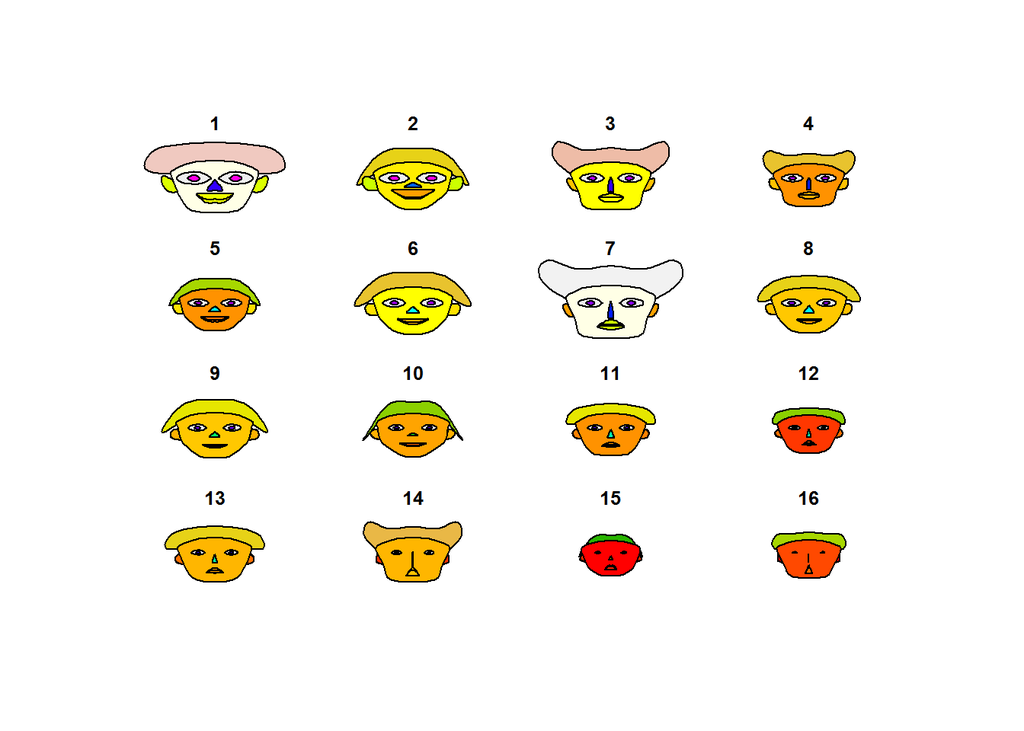

```
## effect of variables:
##  modified item       Var
##  "height of face   " "TotPts"
##  "width of face    " "PtsG"
##  "structure of face" "RushYds"
##  "height of mouth  " "RYdsG"
##  "width of mouth   " "PassYds"
##  "smiling          " "PYdsG"
##  "height of eyes   " "TotYds"
##  "width of eyes    " "YdsG"
##  "height of hair   " "TotPts"
##  "width of hair   "  "PtsG"
##  "style of hair   "  "RushYds"
##  "height of nose  "  "RYdsG"
##  "width of nose   "  "PassYds"
##  "width of ear    "  "PYdsG"
##  "height of ear   "  "TotYds"
```

```r
#head(NFC.off)
#dim(NFC.off)
faces(NFC.off[,2:9])
```

[figure not shown]

```
## effect of variables:
##  modified item       Var
##  "height of face   " "TotPts"
##  "width of face    " "PtsG"
##  "structure of face" "RushYds"
##  "height of mouth  " "RYdsG"
##  "width of mouth   " "PassYds"
##  "smiling          " "PYdsG"
##  "height of eyes   " "TotYds"
##  "width of eyes    " "YdsG"
##  "height of hair   " "TotPts"
##  "width of hair   "  "PtsG"
##  "style of hair   "  "RushYds"
##  "height of nose  "  "RYdsG"
##  "width of nose   "  "PassYds"
##  "width of ear    "  "PYdsG"
##  "height of ear   "  "TotYds"
```

```r
faces(NFC.off[,2:9], labels=NFC.off$Team)
```

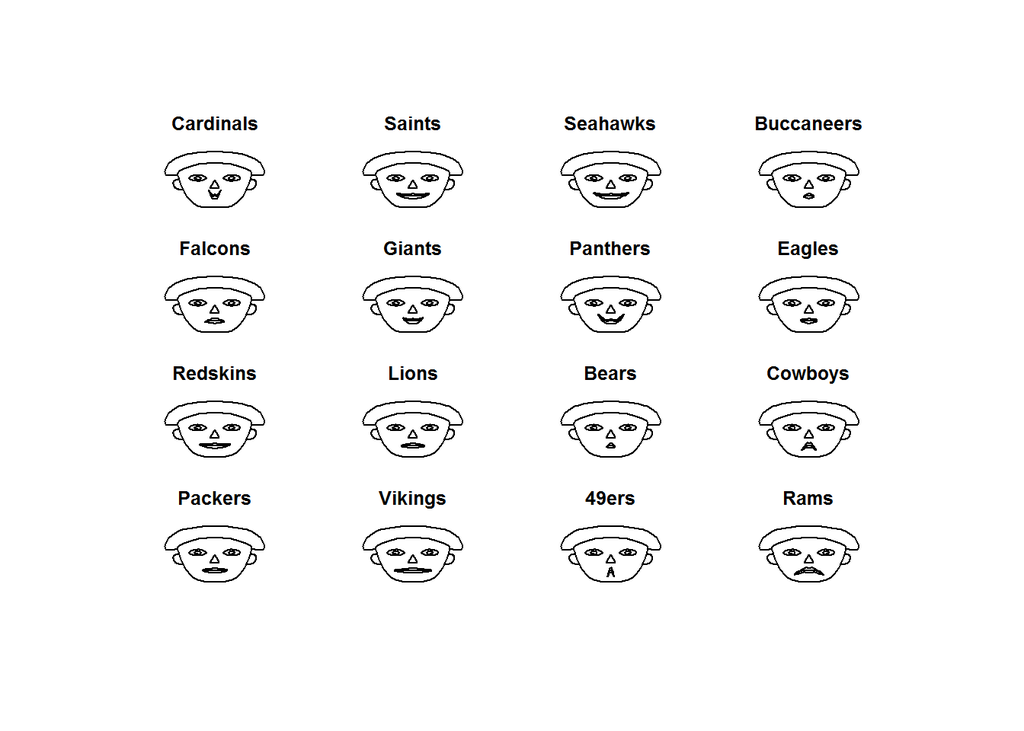

```
## effect of variables:
##  modified item       Var
##  "height of face   " "Var1"
##  "width of face    " "Var2"
##  "structure of face" "Var3"
##  "height of mouth  " "Var4"
##  "width of mouth   " "Var5"
##  "smiling          " "Var6"
##  "height of eyes   " "Var7"
##  "width of eyes    " "Var8"
##  "height of hair   " "Var9"
##  "width of hair   "  "Var10"
##  "style of hair   "  "Var11"
##  "height of nose  "  "Var12"
##  "width of nose   "  "Var13"
##  "width of ear    "  "Var14"
##  "height of ear   "  "Var15"
```

```r
#Those who perform offensively display longer distances and greater number of points.

mat.to.plot3 <- matrix(1,nrow=nrow(NFC.off),ncol=15) #all values are 1 (default)
rownames(mat.to.plot3)<- NFC.off$Team

mat.to.plot3[,5]<-NFC.off[,1]
mat.to.plot3[,6]<-NFC.off[,2]

faces(mat.to.plot3,face.type=0)
```

```r
NFC.def <- read.csv("NFC-DefenseData.csv")
str(NFC.def)
```

```
## 'data.frame':    16 obs. of  9 variables:
##  $ Team   : Factor w/ 16 levels "49ers","Bears",..: 15 4 11 3 16 2 10 7 5 9 ...
##  $ Tot.Pts: int  277 313 308 417 302 397 323 345 374 400 ...
##  $ PtsG   : num  17.3 19.6 19.2 26.1 18.9 24.8 20.2 21.6 23.4 25 ...
##  $ RushYds: int  1304 1460 1415 1606 1748 1934 1905 1680 1934 1808 ...
##  $ RYdsG  : num  81.5 91.2 88.4 100.4 109.2 ...
##  $ PassYds: int  3364 3687 3752 3840 3759 3593 3642 3882 3632 3786 ...
##  $ PYdsG  : num  210 230 234 240 235 ...
##  $ TotYds : int  4668 5147 5167 5446 5507 5527 5547 5562 5566 5594 ...
##  $ YdsG   : num  292 322 323 340 344 ...
```